# Problem Set 02

You can access the .Rmd for the solutions [here](https://github.com/kgfitzgerald/APU_MATH_362/blob/main/PROBLEM_SETS/SOLUTIONS/PS-02-SOLUTIONS.Rmd).

## Summary / Reflection Prompts

*RP1: What were the main concepts covered in this assignment?*

*RP2: What’s one thing you understand better after completing these problems?*

*RP3: What problems gave you the most trouble? What was difficult about them/where did you get stuck?*

## Exercise 1

### Part a

```r
n1 <- 1028
n2 <- 1041
y1 <- 617
y2 <- 694

p1hat <- y1/n1
p2hat <- y2/n2
```

$$\hat{p}_1 = \frac{617}{1028} =
0.6001946$$
$$\hat{p}_2 =
\frac{694}{1041} = 0.6666667$$

### Part b

A confidence interval for $p_1 - p_2$ is given by the following formula:

$$(\hat{p}_1 - \hat{p}_2) \pm
z_{\alpha/2}SE(\hat{p}_1 - \hat{p}_2),$$

where
$$SE(\hat{p}_1 - \hat{p}_2) =
\sqrt{\frac{\hat{p}_1(1 - \hat{p}_1)}{n_1} + \frac{\hat{p}_2(1 -
\hat{p}_2)}{n_2}}$$
.

```r
z <- qnorm(.975)
SE <- sqrt((p1hat*(1 - p1hat)/n1 + p2hat*(1 - p2hat)/n2))

CI_lb <- (p1hat - p2hat) - z*SE
CI_ub <- (p1hat - p2hat) + z*SE
c(CI_lb, CI_ub)
```

```
## [1] -0.10790554 -0.02503868
```

We are 95% confident that the difference in proportions between 2017 and 2018 who favor stricter gun laws is between -0.108 and -0.025. That is, the proportion favoring stricter gun laws was higher in 2018 than in 2017.

## Exercise 2

A confidence interval for $\mu$ is given by
$$\bar{X} \pm
z_{\alpha/2}\frac{\sigma}{\sqrt{n}}$$

Here we have $\sigma^2 = 72$, $n = 8$, and $\bar{X} = 85$.

### Part a

A 99% confidence interval uses a $z_{\alpha/2}$ of 2.5758293.

```r
sigma <- sqrt(72)
n <- 8
xbar <- 85

z <- qnorm(.995)

CI <- c(xbar - z*sigma/sqrt(n), xbar + z*sigma/sqrt(n))
CI
```

```
## [1] 77.27251 92.72749
```

### Part b

Here we can reuse the exact same code, just reset `z` for a 95% confidence interval

```r
z <- qnorm(.975)

CI <- c(xbar - z*sigma/sqrt(n), xbar + z*sigma/sqrt(n))
CI
```

```
## [1] 79.12011 90.87989
```

### Part c

Here we can reuse the exact same code, just reset `z` for a 90% confidence interval

```r
z <- qnorm(.95)

CI <- c(xbar - z*sigma/sqrt(n), xbar + z*sigma/sqrt(n))
CI
```

```
## [1] 80.06544 89.93456
```

### Part d

Here we can reuse the exact same code, just reset `z` for a 80% confidence interval

```r
z <- qnorm(.9)

CI <- c(xbar - z*sigma/sqrt(n), xbar + z*sigma/sqrt(n))
CI
```

```
## [1] 81.15535 88.84465
```

## Exercise 3

$X \sim N(\mu, 9)$ implies that $\sigma = 3$. Note that the statement
$$P(\bar{X} - 1 \lt \mu \lt \bar{X} + 1) =
0.9$$
is in the form
$$P(\bar{X} -
z_{\alpha/2}\frac{\sigma}{\sqrt{n}} \lt \mu \lt \bar{X} +
z_{\alpha/2}\frac{\sigma}{\sqrt{n}}) = 1 - \alpha.$$

Since $1 - \alpha = 0.9$ we have $\alpha = 0.1$, which implies $z_{\alpha/2} = 1.645$. We can set $z_{\alpha/2}\frac{\sigma}{\sqrt{n}}$ equal to 1 (based on the form of the probability statement given above), plug in for $z_{\alpha/2}$ and $\sigma$ and solve for $n$:

$$\begin{aligned}
z_{\alpha/2}\frac{\sigma}{\sqrt{n}} &= 1 \\
1.645 \frac{3}{\sqrt{n}} &= 1 \\
\left((1.645)(3)\right)^2 &= n \\
24.35 &= n
\end{aligned}$$

Since sample size must be a whole number, we round up to $n = 25$. Note we round up because a conservative probability statement is preferable to a liberal one. That is, it is better to understate your confidence than to overstate it.

## Exercise 4

This question is about uncertainty / sampling variability in proportions. Here the proportion of interest is proportion of babies that are boys. Because Hospital A has fewer births per day (smaller sample size), there will be more variability in the proportions. The distribution of proportions for both hospitals will be centered at 50%, but the distribution of Hospital A will be more spread out, resulting in more days with 60% or more are boys.

Another way to think about it, it is more likely just by chance to observe 6 out of 10 rather than to observe 30 out of 50 when the true proportion is 0.5 in both cases, corresponding to expected counts of 5 and 25 respectively.

Here is a quick simulation demonstrating this:

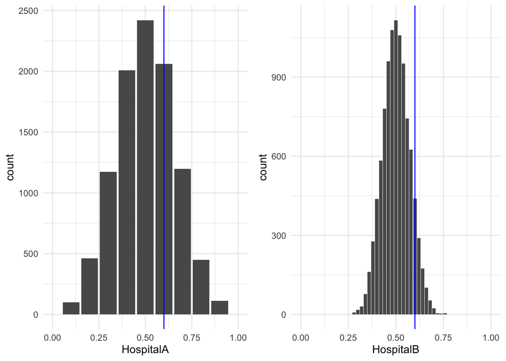

```r
library(tidyverse)
library(cowplot)

data <- data.frame(HospitalA = rbinom(10000, size = 10, prob = .5)/10,
                   HospitalB = rbinom(10000, size = 50, prob = .5)/50)

pA <- ggplot(data, aes(x = HospitalA)) +
  geom_bar() +
  geom_vline(xintercept = 0.6, color = "blue") +
  xlim(0, 1) +
  theme_minimal()

pB <- ggplot(data, aes(x = HospitalB)) +
  geom_bar() +
  geom_vline(xintercept = 0.6, color = "blue") +
  xlim(0, 1) +
  theme_minimal()

plot_grid(pA, pB)
```

```r
data %>%
  summarize(propA = sum(HospitalA > .6)/10000,
            propB = sum(HospitalB > .6)/10000)
```

```
##    propA  propB
## 1 0.1772 0.0654
```

## Exercise 5

### Part a

The observational units are the movies, the variable is the runtime (in minutes). Runtime is a continuous numeric variable.

### Part b

Because this is a numeric variable, we are interested in a mean, $\mu$. Specifically, we are interested in the average runtime for all documentaries in the IMDB database.

### Part c

Because $\sigma$ is unknown, we should use the t-distribution. The confidence interval is given by:

$$\bar{X} \pm
t_{\alpha/2}\frac{s}{\sqrt{n}}$$

### Part d

The only conditions needed for this interval is that the observations are independent (satisfied by random ample), and $n$ is sufficiently large. In this case 50 > 30, and from the shape of the sample distribution, skewness does not appear to be an issue, so this is a sufficient sample size.

### Part e

```r
xbar <- 65.4
s <- 33.5
n <- 50
t <- qt(.975, df = n - 1)

CI <- c(xbar - t*s/sqrt(n), xbar + t*s/sqrt(n))
CI
```

```
## [1] 55.87941 74.92059
```

### Part f

We are 95% confident that the true average runtime for documentaries in the IMDB database is between 55.88 and 74.92

## Exercise 6

A. INCORRECT - this is a statement about individual films

B. INCORRECT - this is a statement about individual films

C. CORRECT, although could be more specific in language

D. CORRECT

E. INCORRECT - this is a statement about individual films

F. INCORRECT - this is a statement about the sample mean rather than the population mean

G. INCORRECT - this is stated as a prediction interval rather than a confidence interval

H. CORRECT - identical to statement D, oops :)

I. INCORRECT - $\mu$ is not random, the *interval* is random.

## Exercise 7

The probability that a sample mean birthweight will be between 3200 and 3400 is larger, because the raw data has larger spread (standard deviation $\sigma$) compared to the sampling distribution of the sample mean (standard deviation $\sigma/\sqrt{n}$). That is, more of the distribution fits in a narrower interval for the sample mean as compared to the raw data.

Here is a quick simulation to demonstrate this:

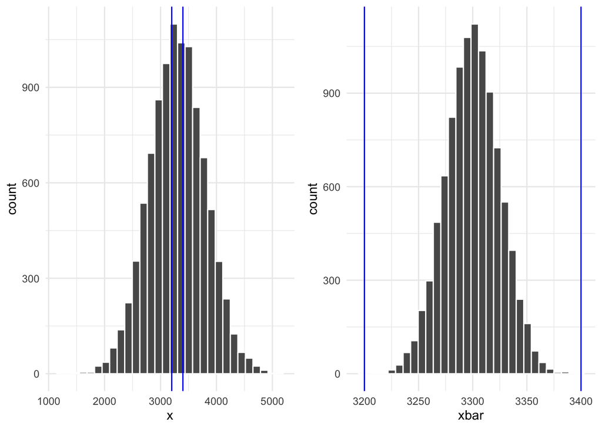

```r
data <- data.frame(x = rnorm(10000, 3300, 500),
                   xbar = rnorm(10000, 3300, 500/sqrt(400)))

pX <- ggplot(data, aes(x = x)) +
  geom_histogram(color = "white") +
  geom_vline(xintercept = 3200, color = "blue") +
  geom_vline(xintercept = 3400, color = "blue") +
  theme_minimal()

pXbar <- ggplot(data, aes(x = xbar)) +
  geom_histogram(color = "white") +
  geom_vline(xintercept = 3200, color = "blue") +
  geom_vline(xintercept = 3400, color = "blue") +
  theme_minimal()

plot_grid(pX, pXbar)
```

```r
data %>%
  summarize(probX = sum(x > 3200 & x < 3400)/10000,
            probXbar = sum(xbar > 3200 & xbar < 3400)/10000)
```

```
##    probX probXbar
## 1 0.1592   0.9999
```

## Exercise 8

Answers will vary

1. What is the average number of potholes in a city block in LA County?
2. What proportion of children under 12 in LA County have been vaccinated for COVID?
3. What is the difference in proportions between eligible voters in CA vs. TX that favor stricter gun laws?